# Musa WRKY Analysis

Ranganath Gudimella

2021-04-05

## Background

```
## Number of WRKY genes:178 ...
```

## Methods

- Map transcriptome reads to WRKY cDNA 178 sequences using Bowtie2
- Counting the number of reads mapped to WRKY genes using Bedtools (Raw counts)
- Raw counts are counts per million (CPM) normalised using `edgeR` package using non-replicate dispersion method (`estimateGLMCommonDisp`)
- Identify differentially expressed (based on pvalue < 0.05) WRKY genes between `Untreatvs1DPI`,`1DPIvs1DMock`, `1DPIvs14DPI`, `14DPIvs14DMock` comparisons.
- Heatmaps were generated using `ComplexHeatmap` with log2 fold changes as row-wise bar plots.

## Coverage of Fusarium treated musa root transcriptomes across WRKY genes

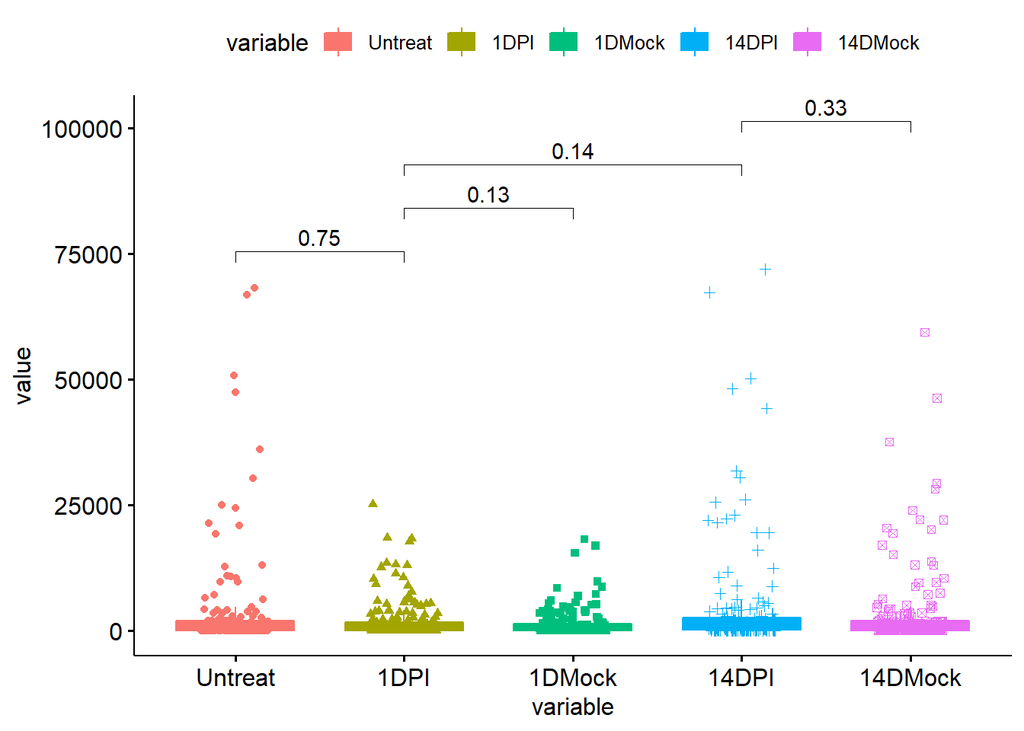

## Heatmap across WRKY genes

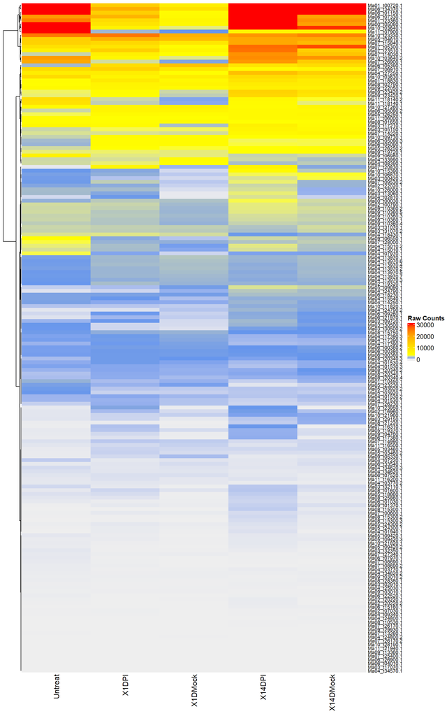

## Log Normalization of data using edgeR

```
##               Untreat X1DPI X1DMock X14DPI X14DMock
## Ma00_t00030.1     970  1538    1330   2790     1935
## Ma00_t05080.1   47348  9142    4606  31713    20464
## Ma01_t00720.1   68078 13455    6840  71887    59345
## Ma01_t10450.1    1014   316     378    210      374
## Ma01_t18830.1    3720  7740    4840   8958     7460
## Ma01_t23360.1   24297 10581    5223  48104    21993
```

```
##          condition
## Untreat    Untreat
## X1DPI         1DPI
## X1DMock     1DMock
## X14DPI       14DPI
## X14DMock   14DMock
```

```
## An object of class "DGEList"
## $counts
##               Untreat X1DPI X1DMock X14DPI X14DMock
## Ma00_t00030.1     970  1538    1330   2790     1935
## Ma00_t05080.1   47348  9142    4606  31713    20464
## Ma01_t00720.1   68078 13455    6840  71887    59345
## Ma01_t10450.1    1014   316     378    210      374
## Ma01_t18830.1    3720  7740    4840   8958     7460
## 173 more rows ...
##
## $samples
##            group lib.size norm.factors
## Untreat  Untreat   621162            1
## X1DPI       1DPI   358865            1
## X1DMock   1DMock   247735            1
## X14DPI     14DPI   768236            1
## X14DMock 14DMock   597621            1
```

```
##                 Untreat     X1DPI   X1DMock    X14DPI  X14DMock
## Ma00_t00030.1  9.923327 10.587778 10.378295 11.446566 10.918863
## Ma00_t05080.1 15.531046 13.158452 12.169612 14.952832 14.320871
## Ma01_t00720.1 16.054922 13.715962 12.739992 16.133463 15.856863
## Ma01_t10450.1  9.987264  8.308339  8.566054  7.721099  8.550747
## Ma01_t18830.1 11.861475 12.918304 12.241089 13.129122 12.865153
## Ma01_t23360.1 14.568550 13.369325 12.350939 15.553899 14.424822
```

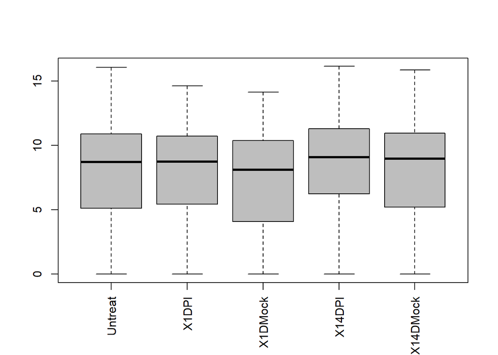

## Distance Matrix

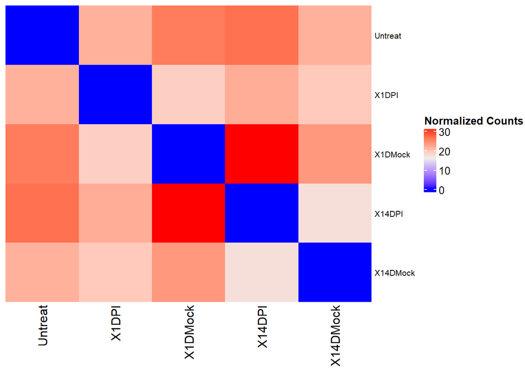

## Differential Expression

```
##               Untreat X1DPI X1DMock X14DPI X14DMock
## Ma00_t00030.1     970  1538    1330   2790     1935
## Ma00_t05080.1   47348  9142    4606  31713    20464
## Ma01_t00720.1   68078 13455    6840  71887    59345
## Ma01_t10450.1    1014   316     378    210      374
## Ma01_t18830.1    3720  7740    4840   8958     7460
## Ma01_t23360.1   24297 10581    5223  48104    21993
```

```
##            group lib.size norm.factors
## Untreat  Untreat   621162    0.7878020
## X1DPI       1DPI   358865    1.2179079
## X1DMock   1DMock   247735    1.2419321
## X14DPI     14DPI   768236    0.8629942
## X14DMock 14DMock   597621    0.9724399
```

## Heatmap with normalized values

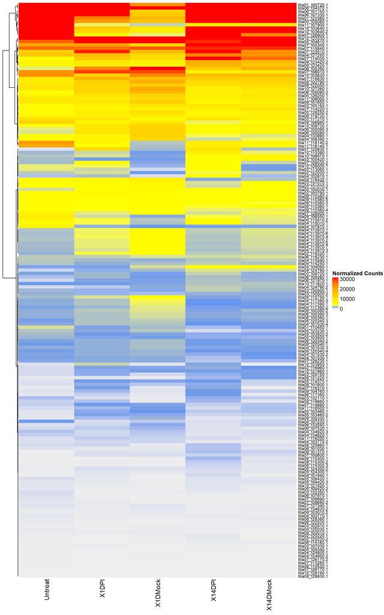

## Untreated vs 1DPI

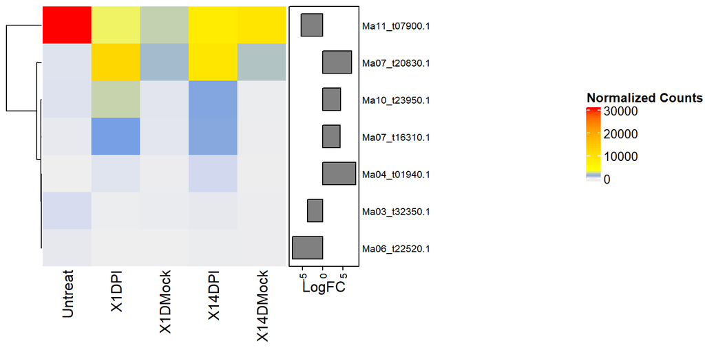

## 1DPI vs 1DMock

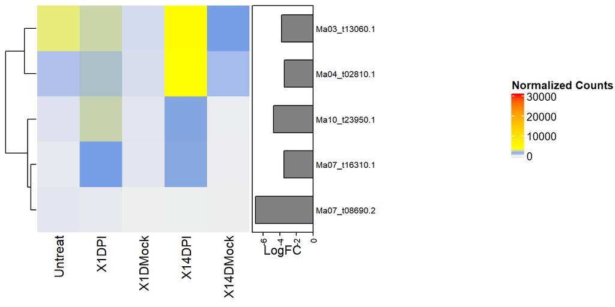

## 1DPI vs 14DPI

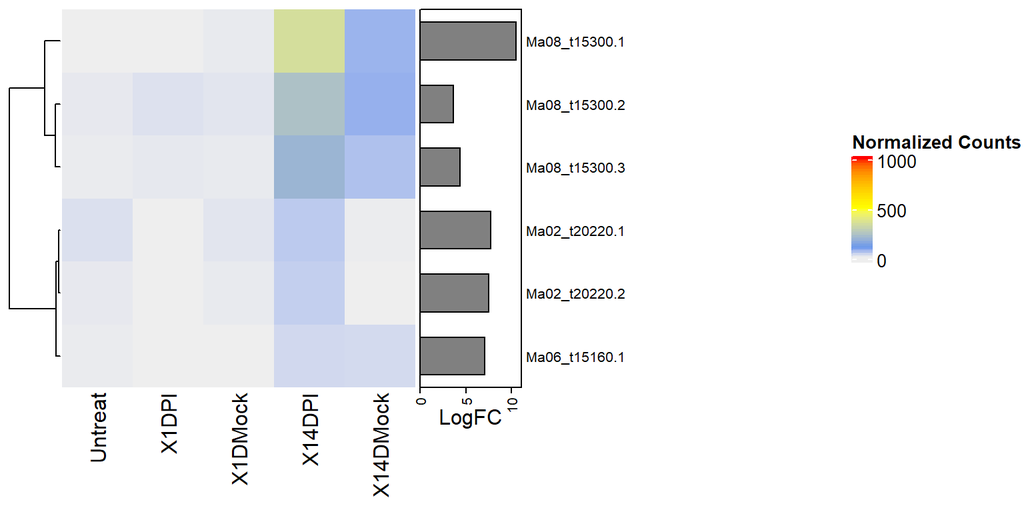

## 14DPI vs 14DMock

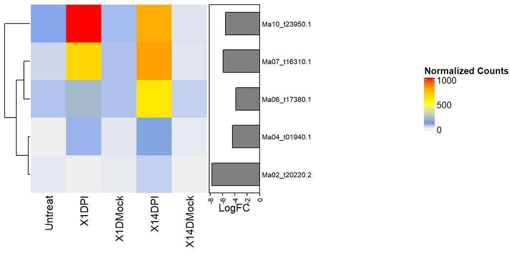

## Conclusion

- Overall distribution of counts across WRKY genes shows low expression in 1DPI and 1DMock compared to Untreatment.
- Differential expression shows upregulation of `Putative Probable WRKY transcription factor 40` in 1DPI
- `Putative Probable WRKY transcription factor 42` is upregulated in 14DPI
- Clearly WRKY family transcription factors are upregulated due to the time course of fusarium infection and limited to certain WRKY gene families.
- **Note: Differential expression is based on non-replicated transcriptome data and the represented genes are with highly enriched transcripts. So, validation of these genes is necessary to support the results.**